*Ugurcan Kalenderoglu / BDA Spring 2019 (Machine Learning Term Project)*

# Unsupervised Learning: Clustering STSL Football Players by Style

The project aims to profile the football players based on the Opta's player game statistics in order to figure out how many different player profiles exist beyond the traditional positions such as goalkeeper, defender, midfielder, and forward. I will focus on only forward players in the context of this study but other positions can be also analysed in the future to compare the model accuracy.

If you follow the football closely, you may have an idea about different style of forward players. Some of them act like a goal machine; they get smartly the position and have strong sense of opportunity to score while some forward players does not score much but contribute to goals scored by other team members. On the other hand there are some forward players who do not have abilities which are highly expected from forwards. At the end of the study, my aim is to make this profiling fed by Opta data which records all actions with ball in addition to traditional metrics such as goal and assists.

Machine learning algorithm like k-means clustering is relevant method to cluster such an unlabeled data.

### Literature Review

There is limited number of similar study conducted on that topic but i managed to find two useful articles which will guide me during the project. In the first article [1], authors try to find relation between value of players and their actions in the game with ball. They criticize the traditional approaches which only consider popular metrics like goals and shots. Conclusion is that it is more suitable to value the player based on the actions that increase the team’s chance of scoring while it would be best to include also actions without ball like positioning.

Second article [2] focuses solely on performance of teams rather than players. They used sixteen different performance metrics from pass accuracy to yellow cards and classified the teams by using k-cluster analysis. Data contains only matches in the UEFA Champions League.

## 1. Reading Data

Opta provided the full dataset for 2017-18 season. Each row represents the statistics of one player for unique game played in each season.

```python
#Read the Data
import pandas as pd
import glob

path = r'pgs_STSL'
all_files = glob.glob(path + "*.csv")

li = []

for filename in all_files:
    df = pd.read_csv(filename, index_col=None, header=0, encoding = "utf-8")
    li.append(df)

pgs_STSL = pd.concat(li, axis=0, ignore_index=True)
```

```python
pgs_STSL.describe().round(1)
```

|  | Match id | Player ID | Team Id | Opposition id | Position Id | Appearances | Time Played | Starts | Substitute On | Substitute Off | ... | Keeper Sweeper Successful | Keeper Sweeper Unsuccessful | Total Shots Conceded | Total Blocked Shots Conceded | Passes Received | Left Foot Shots | Right Foot Shots | GK Long Distribution | GK Short Distribution | Sub Position |
| --- | --- | --- | --- | --- | --- | --- | --- | --- | --- | --- | --- | --- | --- | --- | --- | --- | --- | --- | --- | --- | --- |
| count | 8534.0 | 8534.0 | 8534.0 | 8534.0 | 8534.0 | 8534.0 | 8534.0 | 8534.0 | 8534.0 | 8534.0 | ... | 8534.0 | 8534.0 | 8534.0 | 8534.0 | 8534.0 | 8534.0 | 8534.0 | 8534.0 | 8534.0 | 8534.0 |
| mean | 935738.5 | 92738.0 | 2390.0 | 2390.0 | 3.5 | 1.0 | 70.8 | 0.8 | 0.2 | 0.2 | ... | 0.0 | 0.0 | 0.7 | 0.2 | 24.6 | 0.2 | 0.4 | 0.5 | 0.4 | 1.6 |
| std | 88.4 | 72348.0 | 2451.9 | 2452.1 | 1.5 | 0.0 | 29.1 | 0.4 | 0.4 | 0.4 | ... | 0.2 | 0.1 | 2.7 | 0.8 | 16.2 | 0.5 | 0.7 | 2.1 | 1.7 | 3.4 |
| min | 935586.0 | 4025.0 | 208.0 | 208.0 | 1.0 | 0.0 | 0.0 | 0.0 | 0.0 | 0.0 | ... | 0.0 | 0.0 | 0.0 | 0.0 | 0.0 | 0.0 | 0.0 | 0.0 | 0.0 | 0.0 |
| 25% | 935662.0 | 46640.0 | 383.0 | 383.0 | 2.0 | 1.0 | 57.0 | 1.0 | 0.0 | 0.0 | ... | 0.0 | 0.0 | 0.0 | 0.0 | 12.0 | 0.0 | 0.0 | 0.0 | 0.0 | 0.0 |
| 50% | 935739.0 | 66807.0 | 2133.0 | 2134.0 | 4.0 | 1.0 | 90.0 | 1.0 | 0.0 | 0.0 | ... | 0.0 | 0.0 | 0.0 | 0.0 | 23.0 | 0.0 | 0.0 | 0.0 | 0.0 | 0.0 |
| 75% | 935815.0 | 115860.0 | 3073.0 | 3073.0 | 4.0 | 1.0 | 90.0 | 1.0 | 0.0 | 0.0 | ... | 0.0 | 0.0 | 0.0 | 0.0 | 34.0 | 0.0 | 1.0 | 0.0 | 0.0 | 0.0 |
| max | 935891.0 | 451248.0 | 10248.0 | 10248.0 | 6.0 | 1.0 | 90.0 | 1.0 | 1.0 | 1.0 | ... | 4.0 | 2.0 | 29.0 | 10.0 | 116.0 | 6.0 | 6.0 | 22.0 | 18.0 | 11.0 |

8 rows × 257 columns

Good news: there is no missing value! The dataset consists of 8534 observations and 257 variables.

In the Turkish Super League, there are 34 weeks in one season and 9 matched played in each week. So there are 306 distinct matches in total. Having 8534 observations means there are 27.8 different player stats per match on average.

## 2. Modifying Data

```python
#If we filter only position id's which greater than 5, it will bring only forward players
pgs_STSL = pgs_STSL[pgs_STSL['Position Id']>5]
pgs_STSL.shape
```

```
(1351, 271)
```

Now row number dropped to the 1351.

Let's sum the time played for each player and sort them by total time, so we can also make sense check whether they are right players or not for forward position.

```python
#Group by player and sum total time played, then have a look for only top 5
pgs_STSL.groupby(['Player Forename','Player Surname'])['Time Played'].agg('sum').reset_index().sort_values(['Time Played'],ascending=False).head(5)
```

|  | Player Forename | Player Surname | Time Played |
| --- | --- | --- | --- |
| 13 | Bafétimbi | Gomis | 2805 |
| 57 | Khalid | Boutaïb | 2712 |
| 109 | Umut | Bulut | 2671 |
| 9 | Arouna | Koné | 2555 |
| 33 | Emmanuel | Adebayor | 2409 |

Gomis played almost 83 min per macth on average. Awesome effort compared to others. Anyway, names seem logical and we are on the right way.

I want to drop also stat if player played less than 45 min in the match since it can manipulate the overall results.

```python
#Include only players who played at least 45 min
pgs_STSL = pgs_STSL[pgs_STSL['Time Played']>=45]
```

Now we have filtered our data to inlude only forward players and eliminated the rows that can cause misinterpretation due to low number of minutes played. The next step is to sum all stats by players and having one row for each player.

In order to do that, we should drop the unnecessary variables and the ones which are not suitable to sum up after group by operation.

```python
pgs_STSL = pgs_STSL.drop(['Date','Match id', 'Team', 'Team Id', 'Opposition', 'Opposition id', 'Venue', 'Position Id', 'Appearances', 'CompId', 'SeasId'], axis=1  )
```

```python
#Now we can group the rows by id, surname and forname
#We can sum all other variables
pgs_STSL = pgs_STSL.groupby(['Player ID', 'Player Surname', 'Player Forename']).sum().sort_values(['Time Played'],ascending=False)
pgs_STSL = pgs_STSL.reset_index()

#We can remove player if total time played is less than 350 min for whole season since it is not enough to judge the style
pgs_STSL = pgs_STSL[pgs_STSL['Time Played']>=350]

pgs_STSL
```

|  | Player ID | Player Surname | Player Forename | Time Played | Starts | Substitute On | Substitute Off | Goals | First Goal | Winning Goal | ... | Keeper Sweeper Successful | Keeper Sweeper Unsuccessful | Total Shots Conceded | Total Blocked Shots Conceded | Passes Received | Left Foot Shots | Right Foot Shots | GK Long Distribution | GK Short Distribution | Sub Position |
| --- | --- | --- | --- | --- | --- | --- | --- | --- | --- | --- | --- | --- | --- | --- | --- | --- | --- | --- | --- | --- | --- |
| 0 | 37998 | Gomis | Bafétimbi | 2796 | 32 | 0 | 6 | 28 | 8 | 8 | ... | 0 | 0 | 0 | 0 | 555 | 20 | 62 | 0 | 0 | 0 |
| 1 | 119681 | Boutaïb | Khalid | 2709 | 31 | 0 | 7 | 12 | 4 | 5 | ... | 0 | 0 | 0 | 0 | 735 | 19 | 21 | 0 | 0 | 0 |
| 2 | 40962 | Bulut | Umut | 2638 | 30 | 0 | 8 | 14 | 6 | 4 | ... | 0 | 0 | 0 | 0 | 434 | 4 | 35 | 0 | 0 | 0 |
| 3 | 26921 | Koné | Arouna | 2487 | 29 | 1 | 11 | 12 | 5 | 5 | ... | 0 | 0 | 0 | 0 | 824 | 4 | 33 | 0 | 0 | 9 |
| 4 | 17500 | Adebayor | Emmanuel | 2350 | 27 | 0 | 12 | 14 | 4 | 6 | ... | 0 | 0 | 0 | 0 | 1061 | 4 | 30 | 0 | 0 | 0 |
| 5 | 56376 | Stancu | Bogdan | 2180 | 25 | 0 | 8 | 7 | 4 | 3 | ... | 0 | 0 | 0 | 0 | 418 | 1 | 16 | 0 | 0 | 0 |
| 6 | 8438 | Eto'o | Samuel | 2072 | 26 | 0 | 16 | 12 | 6 | 5 | ... | 0 | 0 | 0 | 0 | 620 | 5 | 31 | 0 | 0 | 0 |
| 7 | 50396 | Seleznyov | Evgen | 1881 | 21 | 3 | 11 | 7 | 3 | 1 | ... | 0 | 0 | 0 | 0 | 495 | 7 | 23 | 0 | 0 | 24 |
| 8 | 39931 | Yilmaz | Burak | 1877 | 21 | 0 | 2 | 17 | 4 | 3 | ... | 0 | 0 | 0 | 0 | 508 | 15 | 32 | 0 | 0 | 0 |
| 9 | 70639 | Jahovic | Adis | 1877 | 21 | 1 | 7 | 15 | 5 | 5 | ... | 0 | 0 | 0 | 0 | 470 | 4 | 29 | 0 | 0 | 9 |
| 10 | 109293 | Doukara | Souleymane | 1822 | 21 | 0 | 4 | 8 | 2 | 2 | ... | 0 | 0 | 0 | 0 | 474 | 12 | 22 | 0 | 0 | 0 |
| 11 | 68862 | Skuletic | Petar | 1720 | 22 | 3 | 12 | 8 | 5 | 4 | ... | 0 | 0 | 0 | 0 | 399 | 19 | 9 | 0 | 0 | 15 |
| 12 | 68657 | Cikalleshi | Sokol | 1243 | 15 | 1 | 9 | 4 | 1 | 1 | ... | 0 | 0 | 0 | 0 | 314 | 8 | 10 | 0 | 0 | 8 |
| 13 | 164011 | Diagne | Mbaye | 1224 | 15 | 0 | 7 | 11 | 3 | 1 | ... | 0 | 0 | 0 | 0 | 252 | 3 | 14 | 0 | 0 | 0 |
| 14 | 42892 | Negredo | Álvaro | 1147 | 16 | 0 | 11 | 5 | 1 | 0 | ... | 0 | 0 | 0 | 0 | 261 | 10 | 5 | 0 | 0 | 0 |
| 15 | 51521 | Yatabaré | Mustapha | 1146 | 13 | 0 | 3 | 4 | 2 | 0 | ... | 0 | 0 | 0 | 0 | 324 | 6 | 19 | 0 | 0 | 0 |
| 16 | 17926 | Soldado | Roberto | 1133 | 14 | 2 | 12 | 6 | 1 | 3 | ... | 0 | 0 | 0 | 0 | 418 | 4 | 22 | 0 | 0 | 13 |
| 17 | 66838 | Tosun | Cenk | 1022 | 11 | 2 | 6 | 6 | 3 | 2 | ... | 0 | 0 | 0 | 0 | 277 | 9 | 20 | 0 | 0 | 16 |
| 18 | 47048 | Keles | Ergin | 994 | 11 | 1 | 2 | 1 | 0 | 0 | ... | 0 | 0 | 0 | 0 | 287 | 4 | 7 | 0 | 0 | 9 |
| 19 | 47412 | Ba | Demba | 939 | 10 | 1 | 1 | 6 | 4 | 2 | ... | 0 | 0 | 0 | 0 | 294 | 8 | 26 | 0 | 0 | 11 |
| 20 | 66738 | Büyük | Adem | 928 | 11 | 0 | 5 | 1 | 0 | 0 | ... | 0 | 0 | 0 | 0 | 279 | 2 | 7 | 0 | 0 | 0 |
| 21 | 176437 | Milosevic | Deni | 873 | 10 | 0 | 2 | 1 | 0 | 0 | ... | 0 | 0 | 0 | 0 | 310 | 1 | 19 | 0 | 0 | 0 |
| 22 | 48337 | N'Doye | Dame | 815 | 8 | 2 | 2 | 4 | 2 | 0 | ... | 0 | 0 | 0 | 0 | 271 | 2 | 16 | 0 | 0 | 20 |
| 23 | 59189 | Kadah | Deniz | 765 | 8 | 1 | 0 | 6 | 2 | 2 | ... | 0 | 0 | 0 | 0 | 222 | 4 | 11 | 0 | 0 | 11 |
| 24 | 108991 | Ghilas | Nabil | 674 | 8 | 0 | 5 | 6 | 1 | 0 | ... | 0 | 0 | 0 | 0 | 202 | 4 | 10 | 0 | 0 | 0 |
| 25 | 165990 | Janssen | Vincent | 668 | 8 | 0 | 4 | 2 | 1 | 1 | ... | 0 | 0 | 0 | 0 | 188 | 7 | 6 | 0 | 0 | 0 |
| 26 | 176729 | Celik | Mugdat | 650 | 6 | 2 | 1 | 3 | 1 | 0 | ... | 0 | 0 | 0 | 0 | 151 | 2 | 3 | 0 | 0 | 18 |
| 27 | 44336 | Feghouli | Sofiane | 599 | 7 | 0 | 3 | 1 | 0 | 0 | ... | 0 | 0 | 0 | 0 | 306 | 2 | 7 | 0 | 0 | 0 |
| 28 | 27677 | Sow | Moussa | 578 | 7 | 1 | 4 | 3 | 1 | 1 | ... | 0 | 0 | 0 | 0 | 114 | 0 | 4 | 0 | 0 | 2 |
| 29 | 80645 | Batdal | Mehmet | 562 | 7 | 1 | 5 | 2 | 0 | 0 | ... | 0 | 0 | 0 | 0 | 197 | 6 | 0 | 0 | 0 | 9 |
| 30 | 37940 | Kembo-Ekoko | Jires | 551 | 7 | 0 | 3 | 2 | 0 | 0 | ... | 0 | 0 | 0 | 0 | 195 | 2 | 9 | 0 | 0 | 0 |
| 31 | 179059 | Murillo | Jhon | 528 | 6 | 1 | 3 | 2 | 0 | 1 | ... | 0 | 0 | 0 | 0 | 125 | 0 | 3 | 0 | 0 | 10 |
| 32 | 212512 | Umar | Aminu | 418 | 5 | 0 | 2 | 1 | 0 | 0 | ... | 0 | 0 | 0 | 0 | 142 | 1 | 4 | 0 | 0 | 0 |
| 33 | 92181 | Manu | Elvis | 398 | 2 | 5 | 1 | 1 | 0 | 0 | ... | 0 | 0 | 0 | 0 | 107 | 4 | 5 | 0 | 0 | 48 |
| 34 | 42181 | Derdiyok | Eren | 396 | 4 | 1 | 1 | 2 | 1 | 1 | ... | 0 | 0 | 0 | 0 | 94 | 4 | 2 | 0 | 0 | 6 |
| 35 | 37852 | Valbuena | Mathieu | 378 | 5 | 0 | 4 | 0 | 0 | 0 | ... | 0 | 0 | 0 | 0 | 247 | 1 | 5 | 0 | 0 | 0 |
| 36 | 156293 | Muriqi | Vedat | 352 | 4 | 0 | 1 | 2 | 1 | 0 | ... | 0 | 0 | 0 | 0 | 88 | 2 | 0 | 0 | 0 | 0 |

37 rows × 252 columns

As we can see from the data, total time on the pitch varies significantly among players. So we need to convert all variables to the something like 'per match or 90 min.' metrics.

```python
#New column can be generated to get number of matches played (total min played divided by 90 min.)
pgs_STSL = pgs_STSL.rename(index=str, columns={'Time Played': 'time_played'})
pgs_STSL['avg_game'] = pgs_STSL['time_played'] / 90
pgs_STSL.head()
```

|  | Player ID | Player Surname | Player Forename | time_played | Starts | Substitute On | Substitute Off | Goals | First Goal | Winning Goal | ... | Keeper Sweeper Unsuccessful | Total Shots Conceded | Total Blocked Shots Conceded | Passes Received | Left Foot Shots | Right Foot Shots | GK Long Distribution | GK Short Distribution | Sub Position | avg_game |
| --- | --- | --- | --- | --- | --- | --- | --- | --- | --- | --- | --- | --- | --- | --- | --- | --- | --- | --- | --- | --- | --- |
| 0 | 37998 | Gomis | Bafétimbi | 2796 | 32 | 0 | 6 | 28 | 8 | 8 | ... | 0 | 0 | 0 | 555 | 20 | 62 | 0 | 0 | 0 | 31.066667 |
| 1 | 119681 | Boutaïb | Khalid | 2709 | 31 | 0 | 7 | 12 | 4 | 5 | ... | 0 | 0 | 0 | 735 | 19 | 21 | 0 | 0 | 0 | 30.100000 |
| 2 | 40962 | Bulut | Umut | 2638 | 30 | 0 | 8 | 14 | 6 | 4 | ... | 0 | 0 | 0 | 434 | 4 | 35 | 0 | 0 | 0 | 29.311111 |
| 3 | 26921 | Koné | Arouna | 2487 | 29 | 1 | 11 | 12 | 5 | 5 | ... | 0 | 0 | 0 | 824 | 4 | 33 | 0 | 0 | 9 | 27.633333 |
| 4 | 17500 | Adebayor | Emmanuel | 2350 | 27 | 0 | 12 | 14 | 4 | 6 | ... | 0 | 0 | 0 | 1061 | 4 | 30 | 0 | 0 | 0 | 26.111111 |

5 rows × 253 columns

```python
#Divide all relevant columns by avg number of game which is added in the previous step, in order to have 'per 90 min. stat'
pgs_STSL_2 = pgs_STSL.iloc[:,7:251].div(pgs_STSL.avg_game, axis=0).round(2)

pgs_STSL_2.head()
```

|  | Goals | First Goal | Winning Goal | Shots On Target inc goals | Shots Off Target inc woodwork | Blocked Shots | Penalties Taken | Penalty Goals | Penalties Saved | Penalties Off Target | ... | Saves Collected | Keeper Sweeper Successful | Keeper Sweeper Unsuccessful | Total Shots Conceded | Total Blocked Shots Conceded | Passes Received | Left Foot Shots | Right Foot Shots | GK Long Distribution | GK Short Distribution |
| --- | --- | --- | --- | --- | --- | --- | --- | --- | --- | --- | --- | --- | --- | --- | --- | --- | --- | --- | --- | --- | --- |
| 0 | 0.90 | 0.26 | 0.26 | 1.77 | 1.35 | 0.90 | 0.23 | 0.13 | 0.03 | 0.06 | ... | 0.0 | 0.0 | 0.0 | 0.0 | 0.0 | 17.86 | 0.64 | 2.00 | 0.0 | 0.0 |
| 1 | 0.40 | 0.13 | 0.17 | 0.96 | 0.73 | 0.37 | 0.07 | 0.03 | 0.03 | 0.00 | ... | 0.0 | 0.0 | 0.0 | 0.0 | 0.0 | 24.42 | 0.63 | 0.70 | 0.0 | 0.0 |
| 2 | 0.48 | 0.20 | 0.14 | 1.06 | 1.06 | 0.17 | 0.03 | 0.03 | 0.00 | 0.00 | ... | 0.0 | 0.0 | 0.0 | 0.0 | 0.0 | 14.81 | 0.14 | 1.19 | 0.0 | 0.0 |
| 3 | 0.43 | 0.18 | 0.18 | 1.16 | 0.87 | 0.40 | 0.18 | 0.18 | 0.00 | 0.00 | ... | 0.0 | 0.0 | 0.0 | 0.0 | 0.0 | 29.82 | 0.14 | 1.19 | 0.0 | 0.0 |
| 4 | 0.54 | 0.15 | 0.23 | 1.11 | 0.80 | 0.34 | 0.04 | 0.04 | 0.00 | 0.00 | ... | 0.0 | 0.0 | 0.0 | 0.0 | 0.0 | 40.63 | 0.15 | 1.15 | 0.0 | 0.0 |

5 rows × 244 columns

Measurement of features are different. So we should scale them in order to prevent the model to treat the biggest as most important one.

On the other hand, if there is a player who has unique skills, we would not want to lose that differentiation. WE can have somw cluster only one player belong to it. So RobustScaler can be used there.

```python
#RobustScaler is better when dealing with outliers compared to min-max/standart scaler
from sklearn.preprocessing import RobustScaler
transformer = RobustScaler().fit(pgs_STSL_2)
np_array = transformer.transform(pgs_STSL_2)
pgs_scaled = pd.DataFrame(np_array)
```

```python
pgs_scaled.head()
```

|  | 0 | 1 | 2 | 3 | 4 | 5 | 6 | 7 | 8 | 9 | ... | 234 | 235 | 236 | 237 | 238 | 239 | 240 | 241 | 242 | 243 |
| --- | --- | --- | --- | --- | --- | --- | --- | --- | --- | --- | --- | --- | --- | --- | --- | --- | --- | --- | --- | --- | --- |
| 0 | 2.086957 | 0.545455 | 0.888889 | 1.833333 | 0.676056 | 1.500000 | 0.941176 | 0.769231 | 0.03 | 0.06 | ... | 0.0 | 0.0 | 0.0 | 0.0 | 0.0 | -0.775414 | 0.738095 | 1.232877 | 0.0 | 0.0 |
| 1 | -0.086957 | -0.045455 | 0.388889 | -0.416667 | -0.197183 | -0.058824 | 0.000000 | 0.000000 | 0.03 | 0.00 | ... | 0.0 | 0.0 | 0.0 | 0.0 | 0.0 | 0.000000 | 0.714286 | -0.547945 | 0.0 | 0.0 |
| 2 | 0.260870 | 0.272727 | 0.222222 | -0.138889 | 0.267606 | -0.647059 | -0.235294 | 0.000000 | 0.00 | 0.00 | ... | 0.0 | 0.0 | 0.0 | 0.0 | 0.0 | -1.135934 | -0.452381 | 0.123288 | 0.0 | 0.0 |
| 3 | 0.043478 | 0.181818 | 0.444444 | 0.138889 | 0.000000 | 0.029412 | 0.647059 | 1.153846 | 0.00 | 0.00 | ... | 0.0 | 0.0 | 0.0 | 0.0 | 0.0 | 0.638298 | -0.452381 | 0.123288 | 0.0 | 0.0 |
| 4 | 0.521739 | 0.045455 | 0.722222 | 0.000000 | -0.098592 | -0.147059 | -0.176471 | 0.076923 | 0.00 | 0.00 | ... | 0.0 | 0.0 | 0.0 | 0.0 | 0.0 | 1.916076 | -0.428571 | 0.068493 | 0.0 | 0.0 |

5 rows × 244 columns

```python
#Let's give the names of variables to the scaled one
pgs_scaled.columns=pgs_STSL_2.columns
```

Now we completed feature elimination, group by, feature extraction and scaling steps but lost the key variables: player_id, surname and forename.

```python
#Let's combine the keys for observation by extracting first three columns of previus df and then merging it with scaled one
df1 = pgs_STSL.iloc[:,:3]
df1 = df1.reset_index()
pgs_scaled = pd.concat([df1,pgs_scaled], axis=1)
pgs_scaled.head()
```

|  | index | Player ID | Player Surname | Player Forename | Goals | First Goal | Winning Goal | Shots On Target inc goals | Shots Off Target inc woodwork | Blocked Shots | ... | Saves Collected | Keeper Sweeper Successful | Keeper Sweeper Unsuccessful | Total Shots Conceded | Total Blocked Shots Conceded | Passes Received | Left Foot Shots | Right Foot Shots | GK Long Distribution | GK Short Distribution |
| --- | --- | --- | --- | --- | --- | --- | --- | --- | --- | --- | --- | --- | --- | --- | --- | --- | --- | --- | --- | --- | --- |
| 0 | 0 | 37998 | Gomis | Bafétimbi | 2.086957 | 0.545455 | 0.888889 | 1.833333 | 0.676056 | 1.500000 | ... | 0.0 | 0.0 | 0.0 | 0.0 | 0.0 | -0.775414 | 0.738095 | 1.232877 | 0.0 | 0.0 |
| 1 | 1 | 119681 | Boutaïb | Khalid | -0.086957 | -0.045455 | 0.388889 | -0.416667 | -0.197183 | -0.058824 | ... | 0.0 | 0.0 | 0.0 | 0.0 | 0.0 | 0.000000 | 0.714286 | -0.547945 | 0.0 | 0.0 |
| 2 | 2 | 40962 | Bulut | Umut | 0.260870 | 0.272727 | 0.222222 | -0.138889 | 0.267606 | -0.647059 | ... | 0.0 | 0.0 | 0.0 | 0.0 | 0.0 | -1.135934 | -0.452381 | 0.123288 | 0.0 | 0.0 |
| 3 | 3 | 26921 | Koné | Arouna | 0.043478 | 0.181818 | 0.444444 | 0.138889 | 0.000000 | 0.029412 | ... | 0.0 | 0.0 | 0.0 | 0.0 | 0.0 | 0.638298 | -0.452381 | 0.123288 | 0.0 | 0.0 |
| 4 | 4 | 17500 | Adebayor | Emmanuel | 0.521739 | 0.045455 | 0.722222 | 0.000000 | -0.098592 | -0.147059 | ... | 0.0 | 0.0 | 0.0 | 0.0 | 0.0 | 1.916076 | -0.428571 | 0.068493 | 0.0 | 0.0 |

5 rows × 248 columns

## 3. PCA

We have a lot of features and PCA can help us to reduce dimensionality to have more robust clustering model.

```python
#Load packages
import matplotlib.pyplot as plt # Python defacto plotting library
import seaborn as sns # More snazzy plotting library
%matplotlib inline
import numpy as np

#First three columns are not relevant to put into PCA
pca_data = pgs_scaled.iloc[:, 4:].values
```

```python
#Calculating Eigenvecors and eigenvalues of Covariance matrix
mean_vec = np.mean(pca_data, axis=0)
cov_mat = np.cov(pca_data.T)
eig_vals, eig_vecs = np.linalg.eig(cov_mat)

# Create a list of (eigenvalue, eigenvector) tuples
eig_pairs = [ (np.abs(eig_vals[i]),eig_vecs[:,i]) for i in range(len(eig_vals))]

# Sort from high to low
eig_pairs.sort(key = lambda x: x[0], reverse= True)

# Calculation of Explained Variance from the eigenvalues
tot = sum(eig_vals)
var_exp = [(i/tot)*100 for i in sorted(eig_vals, reverse=True)] # Individual explained variance
cum_var_exp = np.cumsum(var_exp) # Cumulative explained variance
```

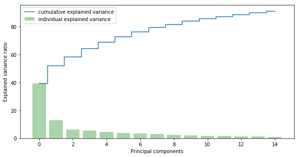

```python
# PLOT OUT THE EXPLAINED VARIANCES SUPERIMPOSED
plt.figure(figsize=(10, 5))
plt.bar(range(0, 15), var_exp[:15], alpha=0.3333, align='center', label='individual explained variance', color = 'g')
plt.step(range(0, 15), cum_var_exp[:15], where='mid',label='cumulative explained variance')
plt.ylabel('Explained variance ratio')
plt.xlabel('Principal components')
plt.legend(loc='best')
plt.show()
```

Now, it would be good to get top features which are highly correlated with pca components for only ones we selected in previous step.

### Reapply the PCA to get to know driving features behind each components

```python
#Extract 5 PCA components
from sklearn.decomposition import PCA
pca = PCA(n_components=5)
principalComponents = pca.fit_transform(pgs_scaled.iloc[:, 4:])

principalDF = pd.DataFrame(data=principalComponents,
                          columns=['PC1', 'PC2', 'PC3', 'PC4', 'PC5'])
```

```python
#Add these PCA components to original dataframe
finalDF = pd.concat([pgs_scaled, principalDF], axis=1)
```

```python
pca.explained_variance_ratio_.sum()
```

```
0.6866406026167193
```

PCA components explains 69% of the variance.

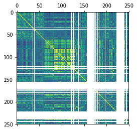

```python
#Plot correlation matrix for all features including PCA
import matplotlib.pyplot as plt

plt.matshow(finalDF.corr())
plt.show()
```

```python
#Get top 2 variables which are highly correlated with first principal component
finalDF[finalDF.columns[4:]].corr()['PC1'][:-10].sort_values(ascending=False).head()
```

```
Successful Crosses Corners in the air      0.969140
Successful Crosses Corners                 0.967488
Unsuccessful Crosses Corners in the air    0.935856
Unsuccessful Crosses Corners               0.933347
Unsuccessful Crosses Corners Left          0.895706
Name: PC1, dtype: float64
```

PC1 is highly correlated with specifications of attacking midfielders. I would expect very limited forward players to belong cluster which has high value on this component.

```python
#Get top 5 variables which are highly correlated with second principal component
finalDF[finalDF.columns[4:]].corr()['PC2'][:-10].sort_values(ascending=False).head()
```

```
Successful Crosses Left            0.713203
Straight Red card                  0.653189
Red Cards                          0.632266
Successful Crosses Corners Left    0.549641
Unsuccessful Dribbles              0.445059
Name: PC2, dtype: float64
```

Correlation with red card stats reveals that player whose cluster has high PC2 value are agressive player or their team prefer to be aggressive.

```python
#Get top 5 variables which are highly correlated with third principal component
finalDF[finalDF.columns[4:]].corr()['PC3'][:-10].sort_values(ascending=False).head()
```

```
Fast Break Attempts      0.549371
Position in Formation    0.454473
Pass Backward            0.435575
Ground Duels won         0.425042
Goals as a substitute    0.406984
Name: PC3, dtype: float64
```

PC3 is highly correlated with fast attacks. They are "contra-attack seekers".

```python
#Get top 5 variables which are highly correlated with fourth principal component
finalDF[finalDF.columns[4:]].corr()['PC4'][:-10].sort_values(ascending=False).head()
```

```
Fast Break Attempts               0.601931
Goals as a substitute             0.423278
Right Foot Shots Off Target       0.420876
Unsuccessful open play crosses    0.403726
Goals from Set Play               0.362853
Name: PC4, dtype: float64
```

PC4 can be associated with "backup saver"s. They can score as a substitute and they are good at scoring from set play.

```python
#Get top 5 variables which are highly correlated with fifth principal component
finalDF[finalDF.columns[4:]].corr()['PC5'][:-10].sort_values(ascending=False).head()
```

```
Shots On Target inc goals       0.763094
First Goal                      0.674938
Big Chances On Target           0.635880
Attempts Open Play on target    0.618730
Right Foot Shots On Target      0.615624
Name: PC5, dtype: float64
```

PC5 players are "Targeted Leaders". They initiate generally scoring of team and their accuracy is higher than average.

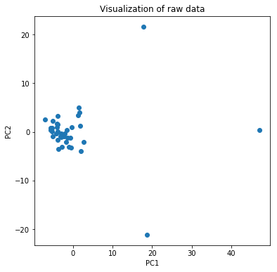

```python
plot_data = finalDF[['PC1','PC2']]

# Plot the data
plt.figure(figsize=(6, 6))
plt.scatter(plot_data.iloc[:, 0], plot_data.iloc[:, 1])
plt.xlabel('PC1')
plt.ylabel('PC2')
plt.title('Visualization of raw data')
```

## 4. Clustering

```python
#Create DF including only necessary columns and 5 PCA components
cluster_data = finalDF[['Player ID','Player Surname','Player Forename','PC1','PC2','PC3','PC4','PC5']]
```

```python
#apply k-means clustering
from sklearn.cluster import KMeans
km_data = cluster_data[['PC1','PC2','PC3']]
km = KMeans(n_clusters=5)
km.fit(km_data)
```

```
KMeans(algorithm='auto', copy_x=True, init='k-means++', max_iter=300,
    n_clusters=5, n_init=10, n_jobs=None, precompute_distances='auto',
    random_state=None, tol=0.0001, verbose=0)
```

### Silhoutee Analysis

Silhouette analysis is a good tool to discover whether there is any trade-off between numbe rof clusters.

```python
#Convert values of kmeans to array
km_data = km_data.values
```

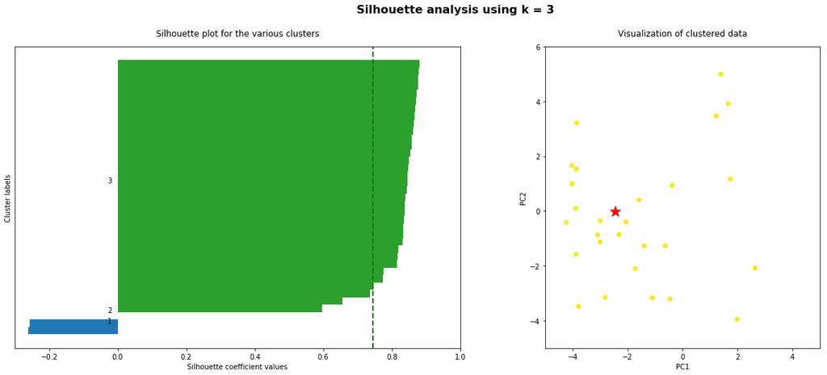

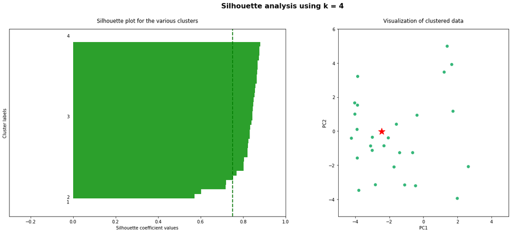

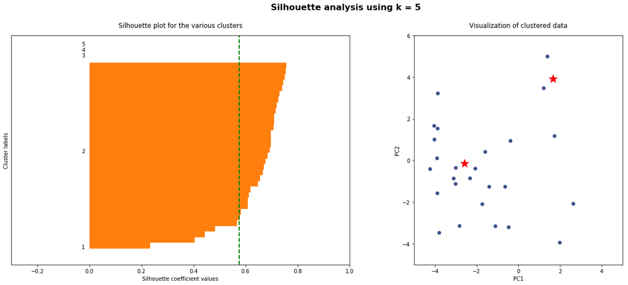

```python
#Plot silhouette analysis for different number of clusters
from sklearn.metrics import silhouette_samples, silhouette_score

for i, k in enumerate([3,4,5]):
    fig, (ax1, ax2) = plt.subplots(1, 2)
    fig.set_size_inches(18, 7)

    # Run the Kmeans algorithm
    km = KMeans(n_clusters=k)
    labels = km.fit_predict(km_data)
    centroids = km.cluster_centers_

    # Get silhouette samples
    silhouette_vals = silhouette_samples(km_data, labels)

    # Silhouette plot
    y_ticks = []
    y_lower, y_upper = 0, 0
    for i, cluster in enumerate(np.unique(labels)):
        cluster_silhouette_vals = silhouette_vals[labels == cluster]
        cluster_silhouette_vals.sort()
        y_upper += len(cluster_silhouette_vals)
        ax1.barh(range(y_lower, y_upper), cluster_silhouette_vals, edgecolor='none', height=1)
        ax1.text(-0.03, (y_lower + y_upper) / 2, str(i + 1))
        y_lower += len(cluster_silhouette_vals)

    # Get the average silhouette score and plot it
    avg_score = np.mean(silhouette_vals)
    ax1.axvline(avg_score, linestyle='--', linewidth=2, color='green')
    ax1.set_yticks([])
    ax1.set_xlim([-0.3, 1])
    ax1.set_xlabel('Silhouette coefficient values')
    ax1.set_ylabel('Cluster labels')
    ax1.set_title('Silhouette plot for the various clusters', y=1.02);

    # Scatter plot of data colored with labels
    ax2.scatter(km_data[:, 0], km_data[:, 1], c=labels)
    ax2.scatter(centroids[:, 0], centroids[:, 1], marker='*', c='r', s=250)
    ax2.set_xlim([-5, 5])
    ax2.set_ylim([-5, 6])
    ax2.set_xlabel('PC1')
    ax2.set_ylabel('PC2')
    ax2.set_title('Visualization of clustered data', y=1.02)
    ax2.set_aspect('equal')
    plt.tight_layout()
    plt.suptitle(f'Silhouette analysis using k = {k}',
                 fontsize=16, fontweight='semibold', y=1.05);
```

```python
#Apply kmeans for 4 clusters
km = KMeans(n_clusters=4)
labels = km.fit_predict(km_data)
```

```python
#Combine cluster labels with initial df
clustered_data = pd.concat([cluster_data, pd.DataFrame(labels)], axis=1)
```

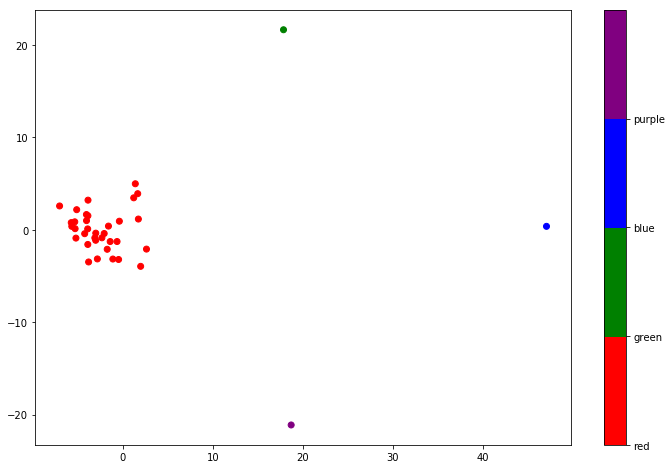

```python
#Plot clusters onto axis of first two PCA components
import matplotlib
import matplotlib.pyplot as plt
x=clustered_data['PC1'].values
y=clustered_data['PC2'].values

colors = ['red','green','blue','purple']

fig = plt.figure(figsize=(12,8))
plt.scatter(x, y, c=labels, cmap=matplotlib.colors.ListedColormap(colors))

cb = plt.colorbar()
loc = np.arange(0,max(labels),max(labels)/float(len(colors)))
cb.set_ticks(loc)
cb.set_ticklabels(colors)
```

## 5. Output Review

```python
#Get to know players who belong to first cluster
clustered_data.loc[clustered_data.iloc[:,8] == 0]
```

|  | Player ID | Player Surname | Player Forename | PC1 | PC2 | PC3 | PC4 | PC5 | 0 |
| --- | --- | --- | --- | --- | --- | --- | --- | --- | --- |
| 0 | 37998 | Gomis | Bafétimbi | -7.008821 | 2.583326 | -0.596304 | 2.721487 | 5.118425 | 0 |
| 1 | 119681 | Boutaïb | Khalid | -1.390018 | -1.267176 | -0.671437 | -2.947575 | -1.010447 | 0 |
| 2 | 40962 | Bulut | Umut | -5.653456 | 0.376547 | -1.519685 | 0.473054 | -1.188745 | 0 |
| 3 | 26921 | Koné | Arouna | -3.093589 | -0.870287 | -0.155183 | -0.600926 | 0.635065 | 0 |
| 4 | 17500 | Adebayor | Emmanuel | -2.309417 | -0.862014 | 1.475479 | -0.958690 | 0.477203 | 0 |
| 5 | 56376 | Stancu | Bogdan | 1.742218 | 1.166989 | -1.714111 | 2.087603 | -4.031367 | 0 |
| 6 | 8438 | Eto'o | Samuel | -2.991155 | -0.360370 | 0.561451 | -0.589820 | -1.020091 | 0 |
| 7 | 50396 | Seleznyov | Evgen | -1.580278 | 0.404867 | 0.885890 | 0.701586 | -0.331842 | 0 |
| 8 | 39931 | Yilmaz | Burak | -5.109942 | 2.179932 | 2.433280 | 5.336182 | 6.359816 | 0 |
| 9 | 70639 | Jahovic | Adis | -2.999286 | -1.130543 | -0.895373 | -1.587138 | 4.024377 | 0 |
| 10 | 109293 | Doukara | Souleymane | 1.224591 | 3.464782 | 0.822874 | 0.944155 | -0.644057 | 0 |
| 11 | 68862 | Skuletic | Petar | -5.285013 | 0.126240 | -0.003023 | -3.839635 | -0.153705 | 0 |
| 12 | 68657 | Cikalleshi | Sokol | -2.055462 | -0.397479 | -0.109199 | 2.092565 | -1.261000 | 0 |
| 13 | 164011 | Diagne | Mbaye | -4.027680 | 1.655187 | -2.792905 | -0.778502 | 3.213703 | 0 |
| 14 | 42892 | Negredo | Álvaro | -3.888756 | 0.099615 | -0.554130 | -3.779868 | -0.051370 | 0 |
| 15 | 51521 | Yatabaré | Mustapha | -2.812440 | -3.149151 | -1.899792 | -0.693341 | 0.808763 | 0 |
| 16 | 17926 | Soldado | Roberto | -0.455894 | -3.209491 | -0.939247 | 0.829475 | 1.665836 | 0 |
| 17 | 66838 | Tosun | Cenk | -3.852466 | 3.211664 | -0.746395 | -0.140343 | 3.346863 | 0 |
| 18 | 47048 | Keles | Ergin | -4.222049 | -0.417321 | 2.032352 | -2.359648 | -4.610678 | 0 |
| 19 | 47412 | Ba | Demba | -3.862829 | 1.523690 | 2.397372 | 4.650573 | 6.818235 | 0 |
| 20 | 66738 | Büyük | Adem | 2.641983 | -2.084995 | 4.241754 | -2.440876 | -4.193235 | 0 |
| 21 | 176437 | Milosevic | Deni | -0.625883 | -1.265540 | 1.866273 | -1.298561 | -3.565650 | 0 |
| 22 | 48337 | N'Doye | Dame | -0.370183 | 0.933288 | -1.174016 | -1.838761 | 2.492934 | 0 |
| 23 | 59189 | Kadah | Deniz | -1.719248 | -2.104560 | -2.090883 | -2.618777 | 2.085356 | 0 |
| 24 | 108991 | Ghilas | Nabil | 1.401474 | 4.985435 | -5.395247 | 2.032051 | 1.586480 | 0 |
| 25 | 165990 | Janssen | Vincent | -4.017326 | 0.997050 | 3.002662 | 1.150916 | 3.413536 | 0 |
| 26 | 176729 | Celik | Mugdat | -1.093375 | -3.160063 | -2.023771 | 5.172724 | -1.829055 | 0 |
| 28 | 27677 | Sow | Moussa | -5.194498 | -0.893918 | -0.930572 | 2.143919 | -1.357092 | 0 |
| 29 | 80645 | Batdal | Mehmet | -3.875215 | -1.581551 | 2.179953 | -5.974242 | -3.970363 | 0 |
| 31 | 179059 | Murillo | Jhon | -5.714393 | 0.780715 | 2.284712 | 3.979806 | -5.544642 | 0 |
| 32 | 212512 | Umar | Aminu | 1.994634 | -3.949951 | 2.818227 | -2.294037 | -4.192903 | 0 |
| 33 | 92181 | Manu | Elvis | 1.668476 | 3.912428 | 12.488706 | 8.982193 | -3.717056 | 0 |
| 34 | 42181 | Derdiyok | Eren | -5.324475 | 0.867213 | -1.854721 | -4.462840 | 2.246277 | 0 |
| 36 | 156293 | Muriqi | Vedat | -3.785994 | -3.477583 | -1.013029 | -8.459309 | 0.081738 | 0 |

Most of the players are clustered in the first group. There is no outlier profile there. All of them perform inline with forward profile, some score above average some below but they ar epure forward players who played regularly during the 2017-18 Turkish Super League.

```python
#Get to know players who belong to second cluster
clustered_data.loc[clustered_data.iloc[:,8] == 1].head()
```

|  | Player ID | Player Surname | Player Forename | PC1 | PC2 | PC3 | PC4 | PC5 | 0 |
| --- | --- | --- | --- | --- | --- | --- | --- | --- | --- |
| 30 | 37940 | Kembo-Ekoko | Jires | 17.862208 | 21.651392 | -10.265015 | 1.52376 | -4.910921 | 1 |

```python
#Get to know players who belong to third cluster
clustered_data.loc[clustered_data.iloc[:,8] == 2].head()
```

|  | Player ID | Player Surname | Player Forename | PC1 | PC2 | PC3 | PC4 | PC5 | 0 |
| --- | --- | --- | --- | --- | --- | --- | --- | --- | --- |
| 35 | 37852 | Valbuena | Mathieu | 47.071667 | 0.377866 | 7.156374 | -4.416922 | 4.75961 | 2 |

```python
#Get to know players who belong to fourth cluster
clustered_data.loc[clustered_data.iloc[:,8] == 3].head()
```

|  | Player ID | Player Surname | Player Forename | PC1 | PC2 | PC3 | PC4 | PC5 | 0 |
| --- | --- | --- | --- | --- | --- | --- | --- | --- | --- |
| 27 | 44336 | Feghouli | Sofiane | 18.711892 | -21.116232 | -9.303319 | 7.257763 | -1.549996 | 3 |

Feghouli plays as right winger originally. So he is good at specifications correlated with PC1. He also loves fast break attempts and that explains why he has higher value of PC4. He is not aggressive as Kembo-Ekoko so belonging different cluster makes sense.

### Conclusion

It's hard to judge performance of model when conducting unsupervised learning but output makes sense for this domain. Expert review and comparison with different seasons or leagues can be useful to update the model.

## References

[1] *Decroos, T., Bransen, L., Haaren, J.V., Davis, J. (2018), Actions Speak Louder Than Goals: Valuing Player Actions in Soccer.*

[2] *Liu, H., Yi, Q., Gimenez, JV., Gomez, MA., Lago-Penas, C. (2015), Performance profiles of football teams in the UEFA Champions League considering situational efficiency. International Journal of Performance Analysis in Sport, pp. 371-390.*